# Homework 3

```r
# Load required libraries
library(outliers)
library(ggplot2)
library(qcc)
library(rlist)
```

## Question 5.1

Using crime data from the file uscrime.txt (http://www.statsci.org/data/general/uscrime.txt, description at http://www.statsci.org/data/general/uscrime.html), test to see whether there are any outliers in the last column (number of crimes per 100,000 people). Use the grubbs.test function in the outliers package in R.

Load US crime data into dataframe

```r
directory <- "C:/Users/Clayton/Documents/Gatech/ISYE 6501 Intro to Analytics Modelling/Module 6 Change Detection/Homework 3/"
crime_df <- read.table(paste0(directory, "uscrime.txt"), header = T, sep = "\t")
```

Set seed for reproducibility

```r
set.seed(31)
```

To visually look for outliers, plot a box and whiskers plot to see obvious data points that are far away from the whiskers.

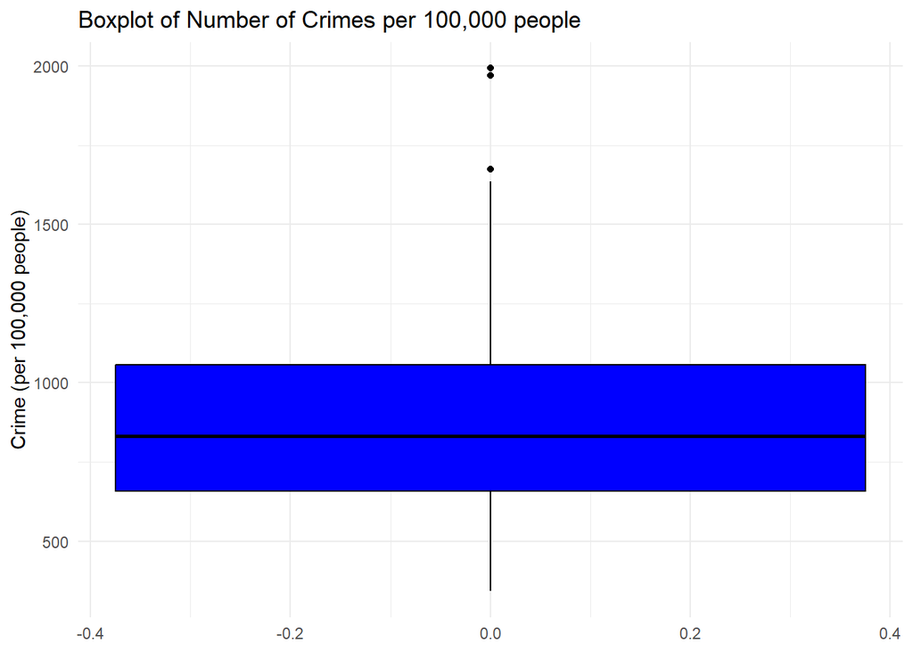

```r
ggplot(crime_df, aes(x = NULL, y = Crime)) +
  geom_boxplot(fill = "blue", color = "black") +
  labs(title = "Boxplot of Number of Crimes per 100,000 people", x = NULL, y = "Crime (per 100,000 people)") +
  theme_minimal()
```

From this plot, we see that there are 2 data points around the 2000 range that are far from the top whisker. These data points may be outliers.

```
##       M So   Ed  Po1  Po2    LF   M.F Pop  NW    U1  U2 Wealth Ineq     Prob
## 4  13.6  0 12.1 14.9 14.1 0.577  99.4 157 8.0 0.102 3.9   6730 16.7 0.015801
## 26 13.1  0 12.1 16.0 14.3 0.631 107.1   3 7.7 0.102 4.1   6740 15.2 0.041698
##       Time Crime
## 4  29.9012  1969
## 26 22.1005  1993
```

We can verify them using the grubbs.test function

```r
outlier_result <- grubbs.test(crime_df$Crime)
```

```
##
##  Grubbs test for one outlier
##
## data:  crime_df$Crime
## G = 2.81287, U = 0.82426, p-value = 0.07887
## alternative hypothesis: highest value 1993 is an outlier
```

Since these 2 points have a p-value of more than 0.05, we cannot reject the null hypothesis that they are not outliers. Therefore, we can conclude that there are no outliers in this dataset.

```r
outliers <- crime_df$Crime[outlier_result$outliers]
```

```
## integer(0)
```

## Question 6.1

Describe a situation or problem from your job, everyday life, current events, etc., for which a Change Detection model would be appropriate. Applying the CUSUM technique, how would you choose the critical value and the threshold?

**A:** In my job in the food delivery industry, one of the key operational metrics that we track is the proportion of delayed food delivery orders. Ideally, this value should decrease or remain constant over time; if it increases over an extended period of time, it would warrant a deeper look into the reasons for the increased amount of delays. This could be due to poor manpower planning, additional delays by food vendors, or due to uncontrollable factors such as poor weather conditions which would result in longer delivery times.

I would choose a critical value of 0.05 to ensure that the chances of false positives remain low at about 5%, and the threshold for increased proportion of delayed orders can be based on 3 standard deviations above the mean of proportion of delayed order in the past 6 months.

## Question 6.2.a

Using July through October daily-high-temperature data for Atlanta for 1996 through 2015, use a CUSUM approach to identify when unofficial summer ends (i.e., when the weather starts cooling off) each year. You can get the data that you need from the file temps.txt or online, for example at http://www.iweathernet.com/atlanta-weather-records or https://www.wunderground.com/history/airport/KFTY/2015/7/1/CustomHistory.html . You can use R if you’d like, but it’s straightforward enough that an Excel spreadsheet can easily do the job too.

Load temperature data into dataframe

```r
temps_df <- read.table(paste0(directory, "temps.txt"), header = T, sep = "\t")
```

To identify when unofficial summer ends for each year, we will need to do a CUSUM loop for each year of data. The rough outline of what the code does is as follows:

- Loops through all 20 years of temperature data
- Use the CUSUM function for each year of data; the threshold used here is 17 standard error as I found that this threshold can reduce some of the clear false positives
- With the CUSUM output, we loop through each day of the year to identify the first day (or index) where the temperature is below 17 standard error
- After identifying the first day of the unofficial summer end, we append the year and the day when summer unofficially ended into a new dataframe called `first_dip_df`
- After all the loops are complete, we will get the `first_dip_df` populated with the unofficial summer end date for each year

```r
for (year in 2:21) {
  temps <- cusum(temps_df[year], decision.interval = 17)

  for (i in 1:length(temps$neg)) {
    if (temps$neg[i] < -17) {
      first_dip_index <- i
      break
    }
  }

  if (year == 2) {
    first_dip_df <- data.frame(colnames(temps_df[year]), temps_df[first_dip_index, ]$DAY)
    names(first_dip_df) <- c("year", "day")
  } else {
    new_first_dip_df <- data.frame(colnames(temps_df[year]), temps_df[first_dip_index, ]$DAY)
    names(new_first_dip_df) <- c("year", "day")
    first_dip_df <- rbind(first_dip_df, new_first_dip_df)
  }
}
```

The dataframe below shows the unofficial summer end date for each year.

```
##     year    day
## 1  X1996  1-Oct
## 2  X1997 28-Sep
## 3  X1998  8-Oct
## 4  X1999 29-Sep
## 5  X2000 17-Sep
## 6  X2001 30-Sep
## 7  X2002 30-Sep
## 8  X2003  2-Oct
## 9  X2004 28-Sep
## 10 X2005  9-Oct
## 11 X2006  7-Oct
## 12 X2007  3-Oct
## 13 X2008 14-Oct
## 14 X2009 12-Oct
## 15 X2010  1-Oct
## 16 X2011 20-Sep
## 17 X2012  7-Oct
## 18 X2013 16-Oct
## 19 X2014 29-Sep
## 20 X2015 26-Sep
```

## Question 6.2.b

Use a CUSUM approach to make a judgment of whether Atlanta’s summer climate has gotten warmer in that time (and if so, when).

For this question, we will need to repeat what was done in Q6.2.a to identify the summer period of each year. We will need to do a CUSUM loop again and the outline of each step of the code is as follows:

- Loops through all 20 years of temperature data
- Use the CUSUM function for each year of data; the threshold used here is 17 standard error
- With the CUSUM output, we loop through each day of the year to identify the first day (or index) where the temperature is below 17 standard error
- After identifying the first day of the unofficial summer end, we calculate the average temperature of the entire summer period for the year (i.e. from the first row to the first index where temperature drops below 17 standard error)
- With the average summer temperature, we append the year and the average summer temperature into a new dataframe called `yearly_temps_df`
- After all the loops are complete, we will get the `yearly_temps_df` populated with the average summer temperature for each year

```r
for (year in 2:21) {
  temps <- cusum(temps_df[year], decision.interval = 17)

  for (i in 1:length(temps$neg)) {
    if (temps$neg[i] < -17) {
      first_dip_index <- i
      break
    }
  }

  avg_temp <- mean(temps_df[1:first_dip_index, year])

  if (year == 2) {
    yearly_temps_df <- data.frame(colnames(temps_df[year]), avg_temp)
    names(yearly_temps_df) <- c("year", "avg_temp")
  } else {
    new_yearly_temps_df <- data.frame(colnames(temps_df[year]), avg_temp)
    names(new_yearly_temps_df) <- c("year", "avg_temp")
    yearly_temps_df <- rbind(yearly_temps_df, new_yearly_temps_df)
  }
}
```

With this new `yearly_temps_df`, we can then do another CUSUM on the yearly summer temperature. For this CUSUM, we will be using a threshold of 2 standard error as this will result in clear changes against the mean.

```r
yearly_temps <- cusum(yearly_temps_df[2], decision.interval = 2)
```

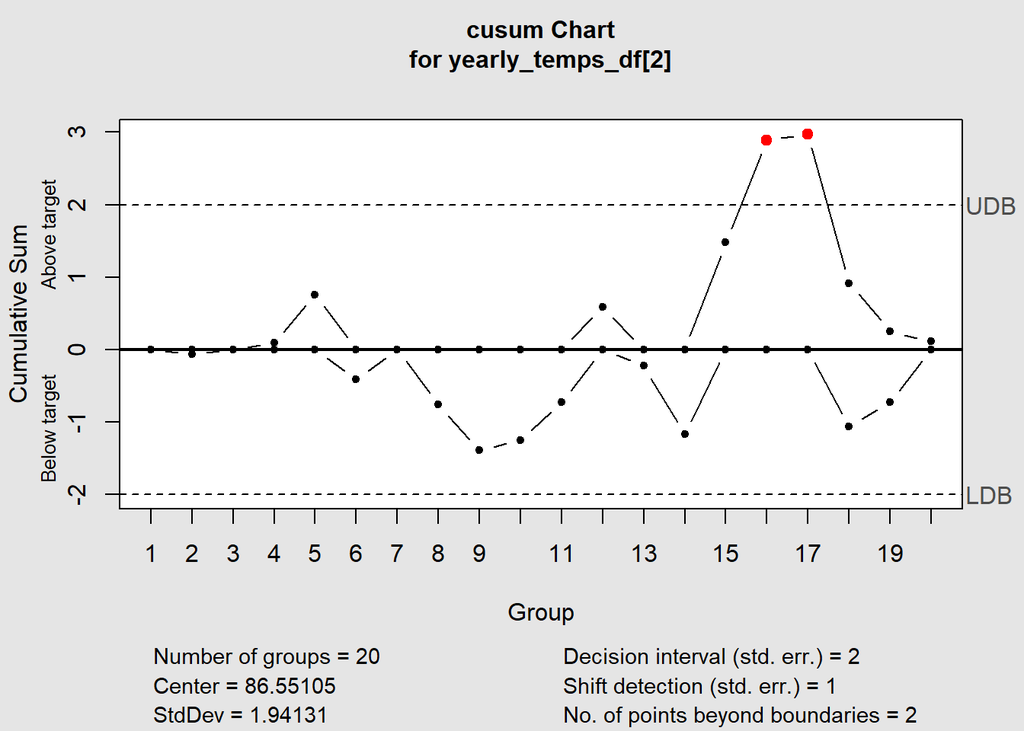

Similarly, looping through the CUSUM output, we can check for each year, whether the average summer temperature has increased above 2 standard error. For this case, we found that the years 2011 and 2012 had much warmer summers between the period of 1996 to 2015.

```r
for (i in 1:length(yearly_temps$neg)) {
  if (yearly_temps$pos[i] > 2) {
    warm_summer_index <- i
    cat("Atlanta's summer climate has gotten warmer in the year", yearly_temps_df[warm_summer_index, ]$year, "\n")
  }
}
```

```
## Atlanta's summer climate has gotten warmer in the year X2011
## Atlanta's summer climate has gotten warmer in the year X2012
```